# Nettoyage des données de Ressources Canada

Author

Victor Nunzi

Published

June 2, 2023

Script *Quarto* visant à nettoyer les données de Ressources Canada (cotes de consommation).

Date du dernier *render* : 2023-06-28

# 1 Données

On affiche l’ensemble des fichiers à nettoyer et fusionner :

```r
data_path <- "C:/Users/victo/OneDrive - ETS/MTR896/TRAVAIL/00_Donnees/Ressources Canada"

list.files <- list.files(data_path)

print(list.files)
```

```
 [1] "AM1995-1999 Cotes de consommation de carburant cinq cycles.csv"
 [2] "AM2000-2004 Cotes de consommation de carburant cinq cycles.csv"
 [3] "AM2005-2009 Cotes de consommation de carburant cinq cycles.csv"
 [4] "AM2010-2014 Cotes de consommation de carburant cinq cycles.csv"
 [5] "AM2012-2023 Véhicules électriques à batterie.csv"
 [6] "AM2012-2023 Véhicules hybrides électriques rechargeables.csv"
 [7] "AM2015 Cotes de consommation de carburant.csv"
 [8] "AM2016 Cotes de consommation de carburant.csv"
 [9] "AM2017 Cotes de consommation de carburant.csv"
[10] "AM2018 Cotes de consommation de carburant.csv"
```

On les lit tous :

```r
for(file in list.files){

  # on simplifie les noms en utilisant uniquement un préfixe :
  df_name <- str_split(file, " ")[[1]][1]
  df_name <- str_replace(df_name, "-", "_")

  # on distingue les fichiers des voitures hybrides et 100% elec, qui ont le même préfixe :
  if(df_name == "AM2012_2023"){
    df_name <- paste0(
      df_name,
      "_",
      stri_trans_general(str = str_split(file, " ")[[1]][3], id = "Latin-ASCII")
    )

    df_name <- str_sub(df_name, 1, 16)
  }

  assign(df_name,
         read.csv(
           paste(data_path, file, sep = "/"),
           header = T, fileEncoding="windows-1252"
         ))
}
```

# 2 Traitement

## 2.1 Nettoyage

On va maintenant nettoyer tous les fichiers dans l’ordre (on commence par `AM1995_1999`). On remarque dans un premier temps que les entêtes sont mal formattés, et sont écrits sur deux lignes :

| ANNÉE | MARQUE | MODÈLE | CATÉGORIE.DE | CYLINDRÉE | CYLINDRES | TRANSMISSION | TYPE.DE | CONSOMMATION.DE.CARBURANT. | X | X.1 | X.2 | ÉMISSIONS.DE.CO2 |
| --- | --- | --- | --- | --- | --- | --- | --- | --- | --- | --- | --- | --- |
| MODÈLE |  |  | VÉHICULE | (L) |  |  | CARBURANT | VILLE (L/100 km) | ROUTE (L/100 km) | COMB (L/100 km) | COMB (mi/gal) | (g/km) |
| 1995 | ACURA | INTEGRA | SOUS-COMPACTE | 1.8 | 4 | A4 | X | 11.6 | 8.3 | 10.1 | 28 | 232 |
| 1995 | ACURA | INTEGRA | SOUS-COMPACTE | 1.8 | 4 | M5 | X | 11.0 | 8.3 | 9.8 | 29 | 225 |
| 1995 | ACURA | INTEGRA GS-R | SOUS-COMPACTE | 1.8 | 4 | M5 | Z | 10.8 | 8.3 | 9.7 | 29 | 223 |
| 1995 | ACURA | LEGEND | COMPACTE | 3.2 | 6 | A4 | Z | 14.2 | 10.5 | 12.5 | 23 | 288 |
| 1995 | ACURA | LEGEND COUPE | COMPACTE | 3.2 | 6 | A4 | Z | 14.6 | 11.0 | 13.0 | 22 | 299 |
| 1995 | ACURA | LEGEND COUPE | COMPACTE | 3.2 | 6 | M6 | Z | 15.0 | 9.9 | 12.7 | 22 | 292 |
| 1995 | ACURA | NSX | DEUX PLACES | 3.0 | 6 | A4 | Z | 15.1 | 10.9 | 13.2 | 21 | 304 |
| 1995 | ACURA | NSX | DEUX PLACES | 3.0 | 6 | M5 | Z | 14.5 | 10.6 | 12.7 | 22 | 292 |
| 1995 | ALFA ROMEO | 164 LS | COMPACTE | 3.0 | 6 | A4 | Z | 17.4 | 11.8 | 14.9 | 19 | 343 |

De même, les explications des données sont à la fin du csv, ce qui est peu pratique :

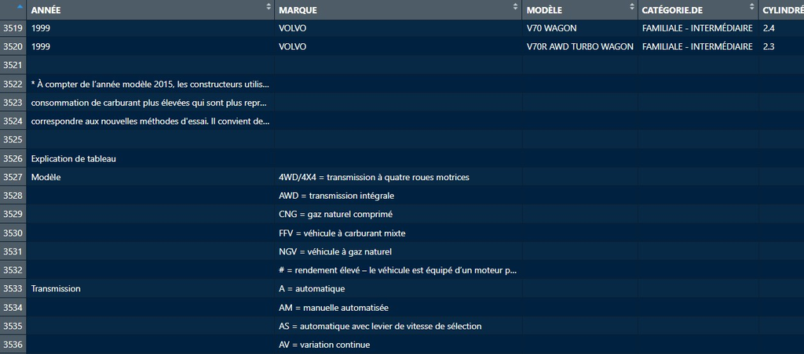

On nettoie tout cela, à commencer par les noms de colonnes :

```r
colnames(AM1995_1999) <-
  c("annee_modele",
    "marque",
    "modele",
    "catVeh",
    "cyl_L",
    "nbCyl",
    "transmission",
    "typeFuel",
    "consoFuel_ville_L100km",
    "consoFuel_route_L100km",
    "consoFuel_comb_L100km",
    "consoFuel_comb_migal",
    "emiCO2_gkm")
```

Et on ne garde que les lignes avec des données :

```r
AM1995_1999 <- AM1995_1999[2:3520,]
```

Affichage (100 premières lignes) :

| annee_modele | marque | modele | catVeh | cyl_L | nbCyl | transmission | typeFuel | consoFuel_ville_L100km | consoFuel_route_L100km | consoFuel_comb_L100km | consoFuel_comb_migal | emiCO2_gkm |
| --- | --- | --- | --- | --- | --- | --- | --- | --- | --- | --- | --- | --- |
| 1995 | ACURA | INTEGRA | SOUS-COMPACTE | 1.8 | 4 | A4 | X | 11.6 | 8.3 | 10.1 | 28 | 232 |
| 1995 | ACURA | INTEGRA | SOUS-COMPACTE | 1.8 | 4 | M5 | X | 11.0 | 8.3 | 9.8 | 29 | 225 |
| 1995 | ACURA | INTEGRA GS-R | SOUS-COMPACTE | 1.8 | 4 | M5 | Z | 10.8 | 8.3 | 9.7 | 29 | 223 |
| 1995 | ACURA | LEGEND | COMPACTE | 3.2 | 6 | A4 | Z | 14.2 | 10.5 | 12.5 | 23 | 288 |
| 1995 | ACURA | LEGEND COUPE | COMPACTE | 3.2 | 6 | A4 | Z | 14.6 | 11.0 | 13.0 | 22 | 299 |
| 1995 | ACURA | LEGEND COUPE | COMPACTE | 3.2 | 6 | M6 | Z | 15.0 | 9.9 | 12.7 | 22 | 292 |
| 1995 | ACURA | NSX | DEUX PLACES | 3.0 | 6 | A4 | Z | 15.1 | 10.9 | 13.2 | 21 | 304 |
| 1995 | ACURA | NSX | DEUX PLACES | 3.0 | 6 | M5 | Z | 14.5 | 10.6 | 12.7 | 22 | 292 |
| 1995 | ALFA ROMEO | 164 LS | COMPACTE | 3.0 | 6 | A4 | Z | 17.4 | 11.8 | 14.9 | 19 | 343 |
| 1995 | ALFA ROMEO | 164 LS | COMPACTE | 3.0 | 6 | M5 | Z | 15.4 | 10.6 | 13.3 | 21 | 306 |

[output cut: 90 more lines]

On fait le même genre de traitement pour les autres jeux de données (en vérifiant d’abord chaque jeu de données individuellement).

Noms de colonnes pour les voitures thermiques :

```r
list.df_names <- list("AM2000_2004",
                      "AM2005_2009",
                      "AM2010_2014",
                      "AM2015",
                      "AM2016",
                      "AM2017",
                      "AM2018")

for(name in list.df_names){

  df.temp <- get(name)

  colnames(df.temp) <-
    c("annee_modele",
      "marque",
      "modele",
      "catVeh",
      "cyl_L",
      "nbCyl",
      "transmission",
      "typeFuel",
      "consoFuel_ville_L100km",
      "consoFuel_route_L100km",
      "consoFuel_comb_L100km",
      "consoFuel_comb_migal",
      "emiCO2_gkm")

  assign(name, df.temp)
}
```

Noms de colonnes pour les voitures hybrides :

```r
colnames(AM2012_2023_hybr) <-
    c("annee_modele",
      "marque",
      "modele",
      "catVeh",
      "moteur",
      "cyl_L",
      "nbCyl",
      "transmission",
      "typeFuel_1",
      "conso_Le100km",
      "autonomie_1_km",
      "tempsRecharge",
      "typeFuel_2",
      "consoFuel_ville_L100km",
      "consoFuel_route_L100km",
      "consoFuel_comb_L100km",
      "autonomie_2_km",
      "emiCO2_gkm")
```

Noms de colonnes pour les voitures électriques :

```r
colnames(AM2012_2023_elec) <-
    c("annee_modele",
      "marque",
      "modele",
      "catVeh",
      "moteur",
      "transmission",
      "typeFuel",
      "consoFuel_ville_kWh100km",
      "consoFuel_route_kWh100km",
      "consoFuel_comb_kWh100km",
      "consoFuel_ville_Le100km",
      "consoFuel_route_Le100km",
      "consoFuel_comb_Le100km",
      "autonomie_km",
      "emiCO2_gkm")
```

Sélection des lignes (et colonnes) avec les données :

```r
AM2000_2004 <- AM2000_2004[2:3777,]
AM2005_2009 <- AM2005_2009[2:5206, 1:13]
AM2010_2014 <- AM2010_2014[2:5360, 1:13]

AM2015 <- AM2015[2:1133, 1:13]
AM2016 <- AM2016[2:1111, 1:13]
AM2017 <- AM2017[2:1059, 1:13]
AM2018 <- AM2018[2:1084, 1:13]

AM2012_2023_hybr <- AM2012_2023_hybr[2:250, 1:18]
AM2012_2023_elec <- AM2012_2023_elec[2:425, 1:15]
```

Enfin, on fusionne les dataframes obtenus :

```r
df.merged.AM <- do.call(bind_rows,
                        list(AM1995_1999,
                             AM2000_2004,
                             AM2005_2009,
                             AM2010_2014,
                             AM2015,
                             AM2016,
                             AM2017,
                             AM2018,
                             AM2012_2023_hybr,
                             AM2012_2023_elec))
```

On ne garde que les colonnes qui permettent la fusion avec les données de la SAAQ :

```r
df.merged.AM <- df.merged.AM %>%
  dplyr::select(c(annee_modele,
           marque,
           modele,
           cyl_L,
           nbCyl,
           typeFuel,
           emiCO2_gkm))
```

Pour concorder avec la marque et le modèle, on réalise les opérations suivantes :

1. passage en majuscules ;
2. suppression des espaces ;
3. suppression des caractères non-alphanumériques ;
4. troncage pour ne garder que les 5 premiers caractères.

```r
df.merged.AM <- df.merged.AM %>%
  mutate(

    across(c(marque, modele),
           toupper),

    across(c(marque, modele),
           ~ str_remove_all(., " ")),

    across(c(marque, modele),
           ~ str_remove_all(., "[^[:alnum:]]")),

    across(c(marque, modele),
           ~ ifelse(str_length(.) > 5, str_sub(., 1, 5), .))
  )
```

On cap le nombre de cylindres à 9, et on passe les données de cylindrée de L à $cm^3$ :

```r
df.merged.AM <- df.merged.AM %>%
  mutate(
    nbCyl = ifelse(nbCyl > 9, 9, nbCyl),

    cyl_cm3 = as.numeric(cyl_L)*1000
  )
```

On recode les types de carburants pour correspondre aux données de la SAAQ :

```r
df.merged.AM <- df.merged.AM %>%
  mutate(
    typ_carb_SAAQ = case_when(
      is.na(typeFuel) ~ "W", # hybride branchable
      typeFuel == "B" ~ "L", # électricité
      typeFuel == "X" ~ "E", # essence ordinaire
      typeFuel == "Z" ~ "E", # essence super
      typeFuel == "D" ~ "D", # diesel
      typeFuel == "E" ~ "T", # éthanol
      typeFuel == "N" ~ "N", # gaz naturel
      TRUE ~ NA_character_
    )
  )

print(table(df.merged.AM$typ_carb_SAAQ, useNA = "ifany"))
```

```
    D     E     L     N     T     W
  364 20852   424    39   987   249
```

```r
print(nrow(AM2012_2023_hybr))
```

```
[1] 249
```

# 3 Enregistrement

```r
write.csv(df.merged.AM,
          "C:/Users/victo/OneDrive - ETS/MTR896/TRAVAIL/99_GitHub/MTR896/emissionsAutomobiles/results/data_cleanedRessourcesCanada_20230606.csv",
          row.names = F)
```